# Exercise-3-eQTL calling

Siming Zhao

2026-05-12

# Before the class

- Download data.

Download from https://rcweb.dartmouth.edu/Szhao/QBS148-statsgen/e3/. It contains gene expression and genotype data from the GEUVADIS dataset. We only used 95 FIN individuals. Only genotype of SNPs and expression for genes on chr22 are used in this demo.

- Install R packages, `MatrixEQTL`, `dplyr`.

```r
install.packages("MatrixEQTL")
install.packages("dplyr")
```

# Explore the data

Load the data:

```r
expr = read.table("data/e3/transformed_expression.fin.chr22.txt", row.names = 1)
snps0 = read.table("data/e3/genotype.chr22.fin.txt", header = T)
snps <- snps0[, -1]
rownames(snps) <- snps0[, 1]
snps <- t(snps)
```

Load gene and snp information.

```r
gene <- read.table("data/e3/gene.chr22.loc.txt", header = T)
genotype <- read.table("data/e3/snp.chr22.loc.txt", header = T)

head(gene)
```

```
             geneid   chr       s1       s2
1 ENSG00000233866.1 chr22 16062157 16063236
2 ENSG00000229286.1 chr22 16076052 16076172
3 ENSG00000235265.1 chr22 16084249 16084826
4 ENSG00000223875.1 chr22 16100517 16124973
5 ENSG00000215270.3 chr22 16122720 16123768
6 ENSG00000206195.4 chr22 16147979 16193004
```

```r
head(genotype)
```

```
                  snp   chr      pos
1 22_16494187_C_A_b37 chr22 16494187
2 22_16494682_G_A_b37 chr22 16494682
3 22_16504399_C_T_b37 chr22 16504399
4 22_16527116_C_T_b37 chr22 16527116
5 22_16870957_C_T_b37 chr22 16870957
6 22_16890307_C_T_b37 chr22 16890307
```

To get a basic idea of the data

```r
head(expr)[,1:5]
```

```
        ENSG00000249263.2 ENSG00000224688.1 ENSG00000075240.12
HG00171       0.259634768          5.278079           4.564746
HG00173       0.006120734          4.671357           2.585686
HG00174       0.155647331          4.219469           3.401698
HG00176       0.111773474          4.613239           4.795421
HG00177       0.617053004          4.761211           2.743071
HG00178       0.205497860          3.880009           4.773510
        ENSG00000099937.6 ENSG00000099998.12
HG00171         0.3862190        -0.00740390
HG00173         0.5421739         0.22562020
HG00174         0.2946133         0.02929838
HG00176         0.4858102         0.08549654
HG00177         0.3661320         0.02403985
HG00178         0.4383820         0.05707943
```

```r
dim(expr)
```

```
[1]  95 633
```

```r
head(snps)[,1:5]
```

```
        22_16494187_C_A_b37 22_16494682_G_A_b37 22_16504399_C_T_b37
HG00171                   0                   0                   1
HG00173                   0                   0                   1
HG00174                   0                   0                   2
HG00176                   0                   0                   2
HG00177                   0                   0                   2
HG00178                   0                   0                   1
        22_16527116_C_T_b37 22_16870957_C_T_b37
HG00171                   0                   0
HG00173                   0                   0
HG00174                   0                   0
HG00176                   0                   0
HG00177                   0                   0
HG00178                   0                   0
```

```r
dim(snps)
```

```
[1]    95 36494
```

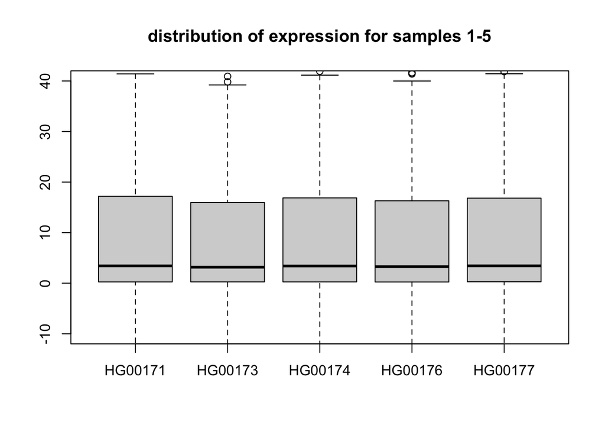

```r
boxplot(t(expr)[,1:5], ylim = c(-10,40), main = "distribution of expression for samples 1-5")
```

Minor allele frequency: the term MAF implies that the allele for which we return the measure has to be the minor (= less common) allele. This means that the MAF is smaller than 0.5 by definition.

So let’s now calculate the MAF for all SNPs among all individuals and correct the returned values so that the value is always given in respect to the minor allele. Then we’ll plot a histogram of the MAFs of all SNPs

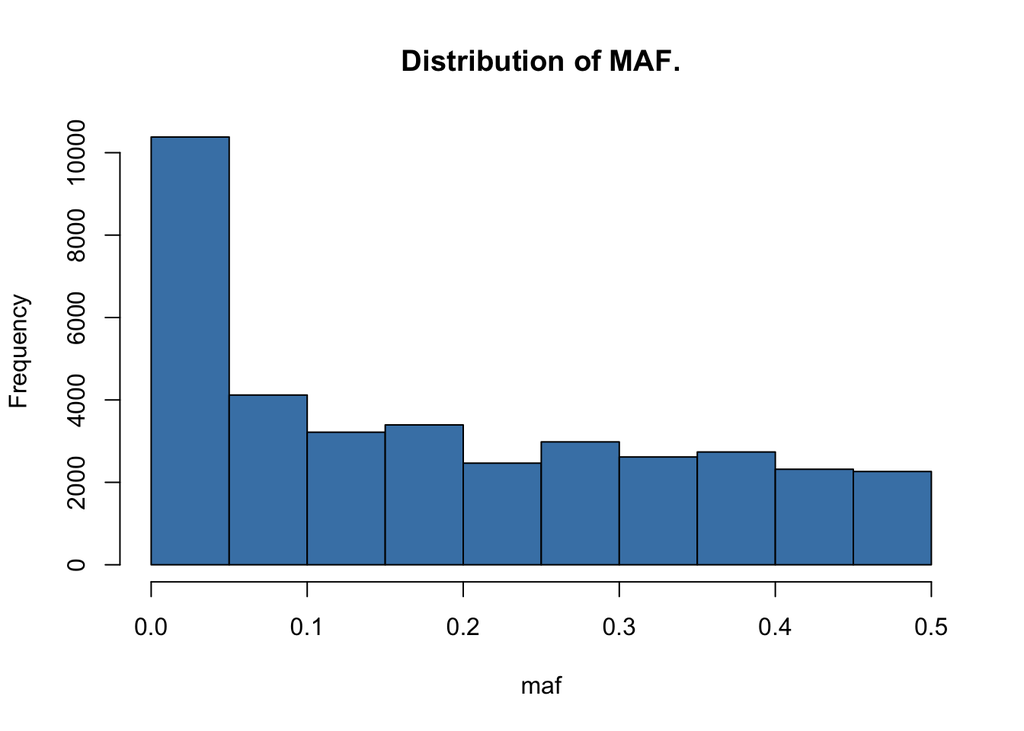

```r
maf = colMeans(snps[,-1])/2

# To ensure we actually get the MAF this needs to be inverted.
maf <- pmin(maf, 1-maf)
names(maf) <- colnames(snps[,-1])

hist(maf, main = "Distribution of MAF.", col = "steelblue")
```

# Data processing

In practice, there will be extensive QCs for genotping and normalization etc for expression data. Genotype and expression data come in all sorts of flavours and preprocessing of this data needs to be done rather carefully. In this short introduction it is not possible to cover this topic in detail. Here, we are assuming the SNP genotype and expression data has passed QC and expression has been normalized. Some additional processing procedures for eQTL mapping:

## Filtering SNPs by MAF

In an eQTL study often a minimum MAF is required. Since MAF essentially reflects how often an allele has been observed in a population, it also defines how often the gene expression levels have been observed for heterozygous and homozygous alleles.

We will filter out SNPs with MAF < 0.05 from this cohort.

## Covariates

There are clinical covariates, such as age, sex. To correct for population structure, we should also include genotype PCs. This is similar to what we have introduced in exercise 1: performing a GWAS.

To correct for unmeasured confounders, we could perform PCA on gene expression and use PCs as covariates.

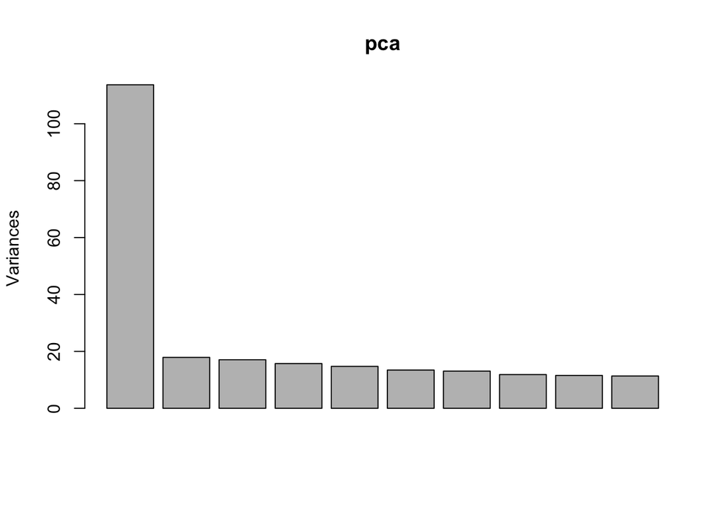

```r
pca <- prcomp(expr, center=TRUE, scale = TRUE)
plot(pca)
```

# A simple eQTL calling example

Match snps and gene expression

```r
snps <- snps[rownames(expr),]
```

Plot expression vs SNP genotype:

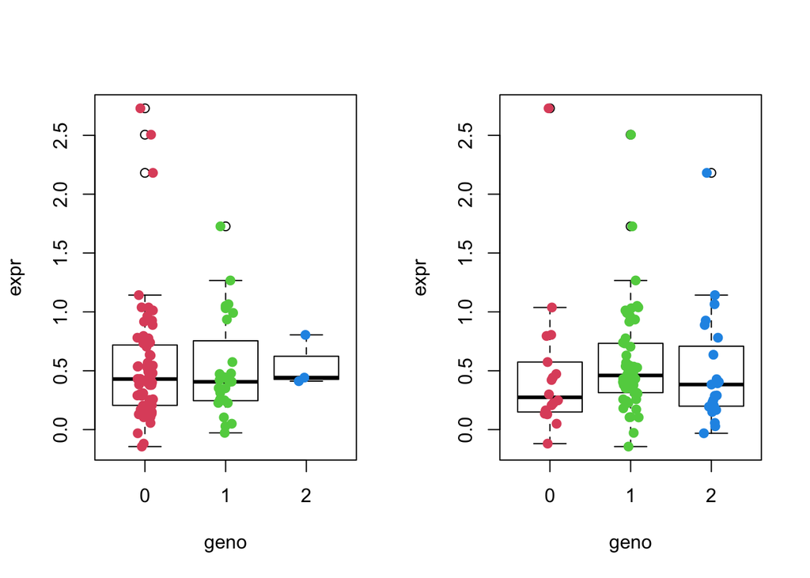

```r
par(mfrow=c(1,2))

df <- cbind(snps[,10], expr[,10])
colnames(df) <- c("geno", "expr")
boxplot(expr ~ geno, data = df, col = "white")
stripchart(expr ~ geno,
           data = df,
           method = "jitter",
           pch = 19,
           col = 2:4,
           vertical = TRUE,
           add = TRUE)

df <- cbind(snps[,15], expr[,10])
colnames(df) <- c("geno", "expr")
boxplot(expr ~ geno, data = df, col = "white")
stripchart(expr ~ geno,
           data = df,
           method = "jitter",
           pch = 19,
           col = 2:4,
           vertical = TRUE,
           add = TRUE)
```

To obtain estimates of the genotypic contribution to gene expression we fit a simple linear regression model of the form $E_i = \beta_0 + \beta G_i + \alpha X_i+ \epsilon$, where $E_i$ is the vector of gene expression values for gene $i$ and $G_i$ is the genotype vector for the SNP $i$. $X_i$ is the covariates. For this demonstration, we will just use the first PC of expression as the only covariate. We are interested in the estimate for $\beta$ which indicates the change in gene expression for each copy of the second allele.

The p-value indicates the significance of the genetic component in the model. Let’s try that for gene 10 with SNP 10 and SNP 15.

```r
lm_10_10 = lm(expr[, 10] ~ snps[, 10] + as.numeric(pca$x[,1]))
summary(lm_10_10)
```

```
Call:
lm(formula = expr[, 10] ~ snps[, 10] + as.numeric(pca$x[, 1]))

Residuals:
    Min      1Q  Median      3Q     Max
-0.6805 -0.2897 -0.1166  0.1894  2.1598

Coefficients:
                       Estimate Std. Error t value Pr(>|t|)
(Intercept)            0.526215   0.059726   8.811 7.26e-14 ***
snps[, 10]             0.015970   0.092946   0.172   0.8640
as.numeric(pca$x[, 1]) 0.008747   0.004743   1.844   0.0684 .
---
Signif. codes:  0 '***' 0.001 '**' 0.01 '*' 0.05 '.' 0.1 ' ' 1

Residual standard error: 0.4835 on 92 degrees of freedom
Multiple R-squared:  0.03584,   Adjusted R-squared:  0.01488
F-statistic:  1.71 on 2 and 92 DF,  p-value: 0.1866
```

```r
lm_10_15 = lm(expr[, 10] ~ snps[, 15] + as.numeric(pca$x[,1]))
summary(lm_10_15)
```

```
Call:
lm(formula = expr[, 10] ~ snps[, 15] + as.numeric(pca$x[, 1]))

Residuals:
    Min      1Q  Median      3Q     Max
-0.6860 -0.2876 -0.1053  0.1859  2.1554

Coefficients:
                        Estimate Std. Error t value Pr(>|t|)
(Intercept)            0.5312957  0.0939233   5.657 1.73e-07 ***
snps[, 15]             0.0006032  0.0757633   0.008   0.9937
as.numeric(pca$x[, 1]) 0.0086111  0.0046777   1.841   0.0689 .
---
Signif. codes:  0 '***' 0.001 '**' 0.01 '*' 0.05 '.' 0.1 ' ' 1

Residual standard error: 0.4836 on 92 degrees of freedom
Multiple R-squared:  0.03553,   Adjusted R-squared:  0.01456
F-statistic: 1.694 on 2 and 92 DF,  p-value: 0.1894
```

So these two models don’t catch any significant effect of explored SNPs and gene expression levels. In fact it is very hard to catch such effects by “manually” exploring real-world genomic data, usually containing tens or hundreds of thousands SNPs and hundreds or thousands gene expressions for large number of samples. Many softwares have been developed to perform eQTL mapping efficiently for thousands of snp-gene pairs, such as [MatrixEQTL](http://www.bios.unc.edu/research/genomic_software/Matrix_eQTL/), [tensorQTL](https://github.com/broadinstitute/tensorqtl) (GPU-accelerated, ~200x faster than CPU-based tools), and [QTLtools](https://qtltools.github.io/qtltools/). Note: fastQTL is no longer actively maintained and has been largely superseded by tensorQTL and QTLtools.

# Fitting many eQTL models with MatrixEQTL

We’ll be using R’s `MatrixEQTL` package which is designed for fast eQTL analysis on large genomic data sets. `MatrixEQTL` can test for association between genotype and gene expression using linear regression with either additive or ANOVA genotype effects. The models can include covariates to account for factors as population stratification, gender, and clinical variables. It also supports models with heteroscedastic and/or correlated errors, false discovery rate estimation and separate treatment of local (cis) and distant (trans) eQTLs. You can learn more about `MatrixEQTL` [here](http://www.bios.unc.edu/research/genomic_software/Matrix_eQTL/).

To perform an eQTL analysis we don’t only need to know the genotype and gene expression values for every sample, but also the genomic positions of genes and SNPs. This is necessary to define which SNPs should be tested against which genes. For cis-eQTL analyses SNPs in proximity to the gene are chosen and for trans-eQTL analyses SNPs further away, or on different chromosomes, are taken into account. The window in cis-eQTL analysis is commonly chosen to be 500kb-1Mb measured from gene’s TSS.

## Prepare files

```r
  # covariates files
  covar <- cbind( "PC1", t(pca$x[,1, drop = F]))
  colnames(covar)[1] <- "id"
  write.table(covar, file = "output/eqtl-covariates.txt", sep = "\t", row.names = F, col.names = T, quote = F)

# SNP files, filter out MAF <0.05 SNPs.
  sid <- names(maf[maf > 0.05])
  snpf <- read.table("data/e3/genotype.chr22.fin.txt", header = T)
  snpf.filtered <- snpf[snpf$id %in% sid,]
  snplocf <- read.table("data/e3/snp.chr22.loc.txt", header = T)
  snplocf.filtered <- snplocf[snplocf$snp %in% sid, ]
  write.table(snpf.filtered, file = "output/genotype.chr22.fin.maf0.05.txt", sep = "\t", row.names = F, col.names = T, quote = F)
  write.table(snplocf.filtered, file = "output/snp.chr22.maf0.05.loc.txt", sep = "\t", row.names = F, col.names = T, quote = F)
```

## Run MatrixEQTL

```r
  suppressMessages(library(MatrixEQTL))

  SNP_file_name <-  "output/genotype.chr22.fin.maf0.05.txt";
  snps_location_file_name <- "output/snp.chr22.maf0.05.loc.txt";
  expression_file_name <- "data/e3/gene_exp.fin.chr22.txt";
  gene_location_file_name <- "data/e3/gene.chr22.loc.txt";
  covariates_file_name <- "output/eqtl-covariates.txt";

  # Output file name
  output_file_name_cis = "output/MatrixEQTL-cis.txt";
  output_file_name_tra = "output/MatrixEQTL-trans.txt";

  ## Settings
  # Linear model to use, modelANOVA, modelLINEAR, or modelLINEAR_CROSS
  useModel = modelLINEAR; # modelANOVA, modelLINEAR, or modelLINEAR_CROSS

  # Error covariance matrix
  # Set to numeric() for identity.
  errorCovariance = numeric();

  # Distance for local gene-SNP pairs
  cisDist = 1e6

  # Only associations significant at this level will be saved
  pvOutputThreshold_cis = 1e-5;
  pvOutputThreshold_tra = 1e-5;


  ## Load genotype data
  snps = SlicedData$new();
  snps$fileDelimiter = "\t"; # the TAB character
  snps$fileOmitCharacters = "NA"; # denote missing values;
  snps$fileSkipRows = 1; # one row of column labels
  snps$fileSkipColumns = 1; # one column of row labels
  snps$fileSliceSize = 2000; # read file in slices of 2,000 rows
  snps$LoadFile(SNP_file_name);

  ## Load gene expression data
  gene = SlicedData$new();
  gene$fileDelimiter = "\t"; # the TAB character
  gene$fileOmitCharacters = "NA"; # denote missing values;
  gene$fileSkipRows = 1; # one row of column labels
  gene$fileSkipColumns = 1; # one column of row labels
  gene$fileSliceSize = 2000; # read file in slices of 2,000 rows
  gene$LoadFile(expression_file_name);

  ## Load covariates
  cvrt = SlicedData$new();
  cvrt$fileDelimiter = "\t"; # the TAB character
  cvrt$fileOmitCharacters = "NA"; # denote missing values;
  cvrt$fileSkipRows = 1; # one row of column labels
  cvrt$fileSkipColumns = 1; # one column of row labels
  if(length(covariates_file_name)>0) {
    cvrt$LoadFile(covariates_file_name);
  }

  ## Run the analysis
  snpspos = read.table(snps_location_file_name, header = TRUE, stringsAsFactors = FALSE);
  genepos = read.table(gene_location_file_name, header = TRUE, stringsAsFactors = FALSE);

me = Matrix_eQTL_main(
  snps = snps,
  gene = gene,
  cvrt = cvrt,
  output_file_name = output_file_name_tra,
  pvOutputThreshold = pvOutputThreshold_tra,
  useModel = useModel,
  errorCovariance = errorCovariance,
  verbose = FALSE,
  output_file_name.cis = output_file_name_cis,
  pvOutputThreshold.cis = pvOutputThreshold_cis,
  snpspos = snpspos,
  genepos = genepos,
  cisDist = cisDist,
  pvalue.hist = TRUE,
  min.pv.by.genesnp = FALSE,
  noFDRsaveMemory = FALSE);

  me_qq = Matrix_eQTL_main(
    snps = snps,
    gene = gene,
    cvrt = cvrt,
    output_file_name = output_file_name_tra,
    pvOutputThreshold = pvOutputThreshold_tra,
    useModel = useModel,
    errorCovariance = errorCovariance,
    verbose = FALSE,
    output_file_name.cis = output_file_name_cis,
    pvOutputThreshold.cis = pvOutputThreshold_cis,
    snpspos = snpspos,
    genepos = genepos,
    cisDist = cisDist,
    pvalue.hist = "qqplot",
    min.pv.by.genesnp = FALSE,
    noFDRsaveMemory = FALSE)

  cat('Analysis done in: ', me$time.in.sec, ' seconds', '\n');
```

```
Analysis done in:  1.945  seconds
```

```r
  head(me$cis$eqtls)
```

```
                 snps              gene statistic       pvalue          FDR
1 22_45711854_G_A_b37 ENSG00000100376.7 -16.12606 1.490974e-28 6.725352e-24
2 22_45726345_A_G_b37 ENSG00000100376.7 -16.12606 1.490974e-28 6.725352e-24
3 22_45731539_C_T_b37 ENSG00000100376.7 -16.12606 1.490974e-28 6.725352e-24
4 22_45736153_G_A_b37 ENSG00000100376.7 -16.12606 1.490974e-28 6.725352e-24
5 22_45740224_G_A_b37 ENSG00000100376.7 -16.12606 1.490974e-28 6.725352e-24
6 22_45741718_C_T_b37 ENSG00000100376.7 -16.12606 1.490974e-28 6.725352e-24
       beta
1 -13.25193
2 -13.25193
3 -13.25193
4 -13.25193
5 -13.25193
6 -13.25193
```

```r
  head(me$trans$eqtls)
```

```
                 snps               gene statistic       pvalue          FDR
1 22_32672837_T_G_b37 ENSG00000183773.10 -7.833864 7.967835e-12 0.0001252302
2 22_48718696_T_C_b37  ENSG00000211659.2  7.039648 3.388673e-10 0.0010651933
3 22_48718828_A_G_b37  ENSG00000211659.2  7.039648 3.388673e-10 0.0010651933
4 22_48718966_G_A_b37  ENSG00000211659.2  7.039648 3.388673e-10 0.0010651933
5 22_48719380_G_A_b37  ENSG00000211659.2  7.039648 3.388673e-10 0.0010651933
6 22_25298169_G_A_b37  ENSG00000202058.1  6.779977 1.130160e-09 0.0029604483
        beta
1  -1.172794
2 363.130340
3 363.130340
4 363.130340
5 363.130340
6   5.466379
```

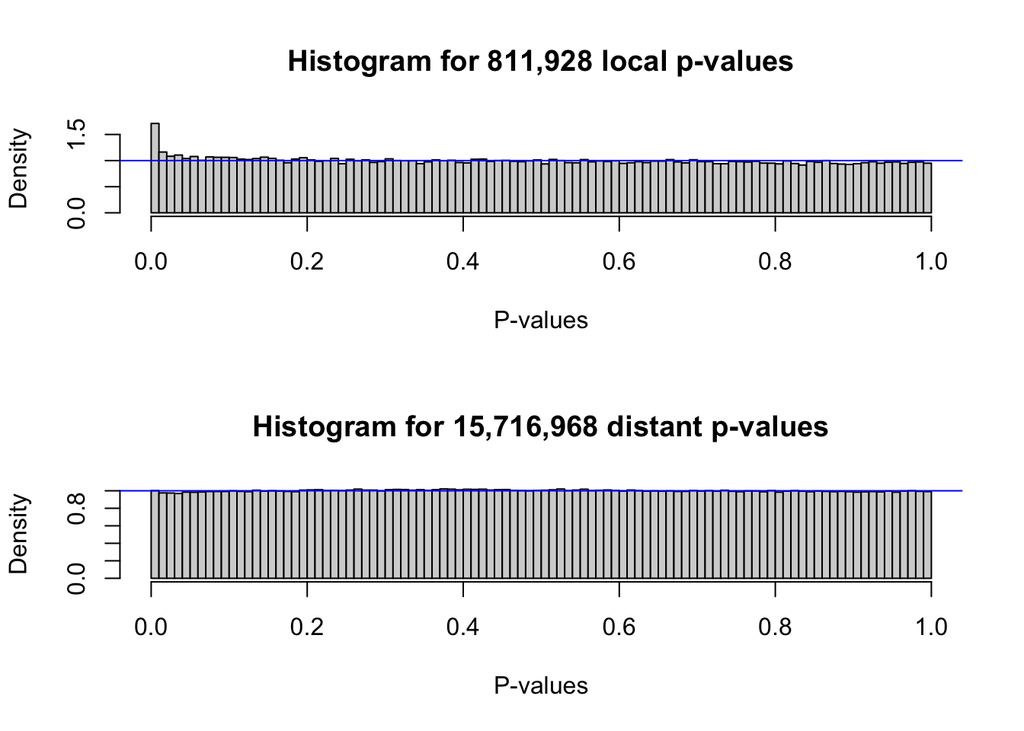

```r
  ## Make the histogram of local and distant p-values
  plot(me)
```

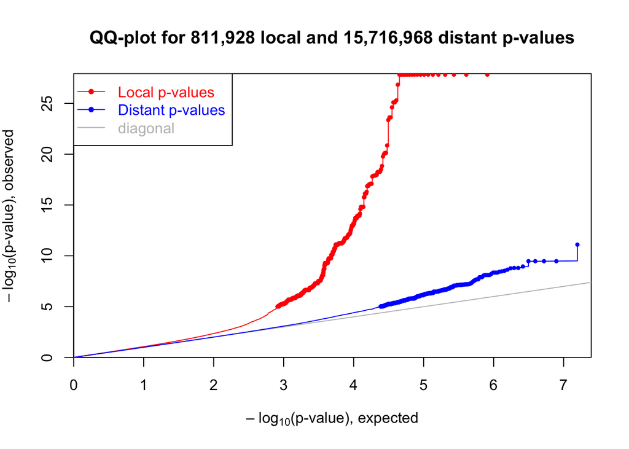

```r
  ## Make the qq-plot of local and distant p-values
  plot(me_qq)
```

## Multiple testing correction

`MatrixEQTL` does this for you automatically and returns the corrected p-value as a false discovery rate (FDR). Common thresholds on FDR are 5% or 10%. Tools like tensorQTL and QTLtools use a permutation-based strategy to obtain gene-level p-values, followed by FDR correction across genes.

## Interpreting eQTL results

Selects at most one associated SNP per gene. If there are many SNPs associated with a gene it is most likely that those SNPs are highly linked to each other (“in high LD”) and therefore they describe the same effect. There are still cases in which genes are regulated by different SNPs independently, this cannot be readily determined from the table produced by `MatrixEQTL`.

- print top eQTLs for genes. Let’s identify which SNPs are (significantly) associated with which genes at a maximum FDR of 5% from the cis-eQTL results. We’ll print a table in which only the lead SNP per gene is given. Also we’ll add the MAF for every SNP in the table.

```r
library(dplyr)

snp_values = read.table(SNP_file_name, row.names=1, header=TRUE)
snp_values = data.frame(snps = rownames(snp_values), snp_values, stringsAsFactors = FALSE)

top_eqtls = filter(me$cis$eqtls, FDR <= 0.05) %>%
  arrange(FDR) %>%
  distinct(gene, .keep_all = TRUE)

mafs = apply(as.matrix(snp_values[-1]),1,mean)/2
mafs = pmin(mafs, 1 - mafs)
mafs = data.frame(snps=names(mafs), maf = mafs)
top_eqtls = left_join(top_eqtls, mafs, by="snps")
head(top_eqtls)
```

```
                 snps               gene  statistic       pvalue          FDR
1 22_45711854_G_A_b37  ENSG00000100376.7 -16.126060 1.490974e-28 6.725352e-24
2 22_41241945_C_T_b37  ENSG00000172404.4  14.772190 5.139381e-26 2.086404e-21
3 22_39747780_G_A_b37 ENSG00000100321.10  11.531146 1.467769e-19 3.724132e-15
4 22_24402321_G_A_b37  ENSG00000184674.7  11.378742 3.030010e-19 7.454999e-15
5 22_26921725_A_G_b37  ENSG00000260065.1  10.655221 9.675930e-18 1.603298e-13
6 22_45809624_C_A_b37  ENSG00000128408.7  -9.192007 1.144721e-14 1.290876e-10
         beta       maf
1 -13.2519275 0.1631579
2   0.1427365 0.4631579
3   3.3888671 0.3421053
4   6.2618570 0.4052632
5   0.4066246 0.4578947
6  -0.5574254 0.3947368
```

## Plot eQTLs

```r
# For this we also need df with expression data
gene_values = read.table(expression_file_name, row.names=1, header=TRUE)
gene_values = data.frame(gene = rownames(gene_values), gene_values, stringsAsFactors = FALSE)

top_snp = top_eqtls$snps[2]
top_gene = as.character(top_eqtls$gene[2])

top_snp_data = filter(snp_values, snps == top_snp)
top_gene_data = filter(gene_values, gene == top_gene)

plot_data = t(bind_rows(top_snp_data[-1], top_gene_data[-1]))
colnames(plot_data) = c("snp", "gene_expr")
plot_data = as.data.frame(plot_data)
plot_data$snp = as.factor(plot_data$snp)
head(plot_data)
```

```
        snp gene_expr
HG00171   2 0.2674373
HG00173   1 0.2209592
HG00174   1 0.2234611
HG00176   2 0.4616005
HG00177   2 0.3368802
HG00178   1 0.2106011
```

```r
lm_top = lm(plot_data[,"gene_expr"] ~ as.numeric(plot_data[,"snp"]))
summary(lm_top)
```

```
Call:
lm(formula = plot_data[, "gene_expr"] ~ as.numeric(plot_data[,
    "snp"]))

Residuals:
     Min       1Q   Median       3Q      Max
-0.22057 -0.03636 -0.01455  0.03381  0.19657

Coefficients:
                               Estimate Std. Error t value Pr(>|t|)
(Intercept)                    -0.03425    0.02099  -1.632    0.106
as.numeric(plot_data[, "snp"])  0.14166    0.01029  13.765   <2e-16 ***
---
Signif. codes:  0 '***' 0.001 '**' 0.01 '*' 0.05 '.' 0.1 ' ' 1

Residual standard error: 0.06708 on 93 degrees of freedom
Multiple R-squared:  0.6708,    Adjusted R-squared:  0.6672
F-statistic: 189.5 on 1 and 93 DF,  p-value: < 2.2e-16
```

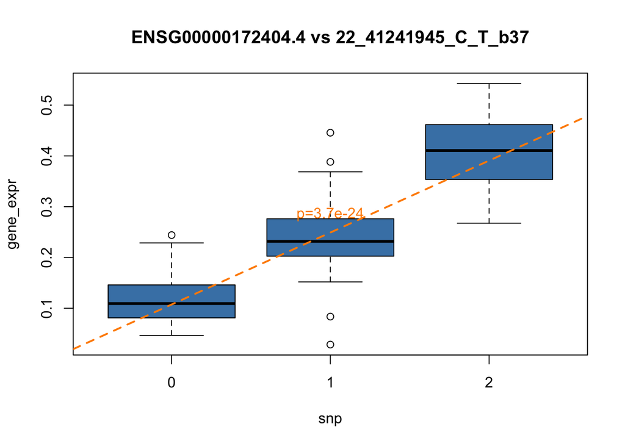

```r
plot(plot_data, col="steelblue",
     main = paste0(top_gene, " vs ", top_snp))
abline(lm_top, col="darkorange", lwd = 2, lty = 2)
y_range = range(plot_data[,"gene_expr"])
  text(x=2, y=y_range[1] + 0.5*diff(y_range), paste0("p=",
  format(summary(lm_top)$coefficients[2,4],
  scientific=TRUE, digits=2)), col = "darkorange")
```

# Citation

Credits go to:

- PredictDB-Tutorial for data: https://github.com/hakyimlab/PredictDB-Tutorial/tree/master
- For code: https://rstudio-pubs-static.s3.amazonaws.com/349118_7519a1b4bb614cf8bdf18e1698033c2a.html#linear_regression_of_genotype_on_phenotype.